# Introduction to Statistics for Astronomers and Physicists

Section 1c: Data Mining Exercise

Dr Angus H Wright

2022-02-08

# Statistics in practice

Choosing which statistic (and analysis methods) to use is frequently determined by the type of data that you are analysing. For the remainder of this chapter, we are going to perform some practical data mining.

For this purpose, I have selected a dataset for us that is **highly relevant to all physics and astronomy students living in Germany in 2021**.

We will be exploring a dataset of:

- Pizza Sizes from two Australian Restaurants in 2012

We will intentionally begin our exploration into this dataset with no additional information. Our goal will be to utilise the various statistics that we have learnt about so far.

# Employing the statistics we’ve learnt so far

We will start by reading in our dataset as a data.frame:

```r
#Read in the pizza dataset with R
library(data.table)
df<-fread("pizzadata.csv")
```

The remainder of this section is going to be a bit of a “choose your own adventure”. I will provide options, and you can vote for which path to go down. We’ll slowly build up a picture of what’s happening in the dataset, and eventually will be able to make an informed choice about which pizza we should have bought when we were in Australia in 2012.

## Example: Choose your own adventure

You are walking through the forest and you come to a small cottage made entirely out of candy! What do you do?

- Option 1: Go inside (to discuss the merits of brick and mortar)
- Option 2: Take a photo, for the ’gram
- Option 3: I’m smart enough to stay away from that…

Let’s get started

# Going inside leads to…

## **A Nobel Prize?!**

After deciding not to unfairly judge someones house without hearing their story, you knock on the door of the candy house.

You’re greeted by an educated young lady who has a lengthy discussion with you about the little understood merits of using candy as sustainable housing.

With your expertise in physics, and her ingenious mind for candy-construction, you pioneer a new form of housing that is able to be revolutionise impoverished communities all over the world.

Your success with the candy-house genius is so profound, that the Nobel committee deems it worthy of not one, but all the nobel prizes on offer: Physics, Chemistry, Economics, Medicine, Peace, and even Literature!

*Congratulations*!

Back

# Taking a photo leads to…

## **Prison?!**

After deciding to take a sneaky photo for the ’gram, you post it with a snappy quip that is sure to get the followers laughing (“I can’t Hansel how cool this house is!”).

Unfortunately for you, the photo is flagged for copyright infringement by the eccentric billionaire known only as “Gretel”.

In retrospect, the house has nothing to do with her, but the wheels are already in motion. She brings the full force of her literature empire down upon you, smearing your name in local newspapers, and filing frivolous lawsuit after frivolous lawsuit.

Eventually, broken and bankrupt from the constant court cases, you are given the option to plead guilty to theft of intellectual property or continue with the never-ending court cases. You don’t see much of a choice…

Why did you have to take that photo?!

Back

# Keeping on walking leads to…

## **DEATH?!**

After deciding not to explore the strange candy house, you decide to keep walking along the forest path.

But it’s getting late, and your phone is low on battery. And you get yourself horribly lost.

Now it’s dark, you have no phone, you’re cold, you can hear wolves gathering…

It’s now that you remember that, for some reason, you’re carrying a backpack filled with raw sausages. *And the animals know*.

You throw the bag and run, but the wolves are quickly finished with the sausages. They hear you running blindly in the distance. And they’re still hungry…

Back

# First Step in (Data-)Mining Pizzas

Let’s start.

You are presented with a dataset that is of Pizza’s in Australia, and no other information. You want to make an informed decision about what pizza to order for your dinner. Pick your first step in analysis:

- Option 1: What columns does the data have?
- Option 2: How many observations are there?
- Option 3: What is the average?

Back to the start

# “What is the average”?

The real question is, what does is mean to take an average of a dataset that we know nothing about?! Probably best to learn some basics about the dataset first…

Back to the start

# Checking the format of the data

It is always sensible to start by asking “what is the format of the data that I’ve been given”.

```r
#Columns of the Pizzas data frame
colnames(df)
```

```
## [1] "Restaurant" "Base"       "Topping"    "Diameter"
```

```r
#Or just print some of the data frame
head(df)
```

| Restaurant | Base | Topping | Diameter |
| --- | --- | --- | --- |
| Dominos | ThinNCrispy | Supreme | 74.6760 |
| Dominos | ThinNCrispy | BBQMeatlovers | 75.2602 |
| Dominos | DeepPan | Hawaiian | 68.7324 |
| Dominos | ThinNCrispy | Supreme | 69.7230 |
| Dominos | ClassicCrust | Hawaiian | 67.5386 |
| Dominos | DeepPan | BBQMeatlovers | 68.9864 |

```r
#Or we can print the structure for the most info
str(df)
```

```
## Classes 'data.table' and 'data.frame':   250 obs. of  4 variables:
##  $ Restaurant: chr  "Dominos" "Dominos" "Dominos" "Dominos" ...
##  $ Base      : chr  "ThinNCrispy" "ThinNCrispy" "DeepPan" "ThinNCrispy" ...
##  $ Topping   : chr  "Supreme" "BBQMeatlovers" "Hawaiian" "Supreme" ...
##  $ Diameter  : num  74.7 75.3 68.7 69.7 67.5 ...
##  - attr(*, ".internal.selfref")=<externalptr>
```

So, we can see that there are $3$ qualitative variables (of character type) and $1$ quantitative variable (of numeric type), and there are 250 observations. It may not be clear yet whether the qualitative variables are nominal or ordinal, though.

What comes next?

# Checking the number of observations

Checking the number of observations of the data is a sensible thing to do to start, but we don’t necessarily need to do this as a stand-alone step. Nonetheless:

```r
#Number of observations of the Pizzas dataset
nrow(df)
```

```
## [1] 250
```

So there are 250 observations within the dataset.

Back to the start

# Analysing the variables

We now know the variables that are present in our dataset. The next step is to learn a little more about our data.

Which personality do you think suits you best?

- Option 1: The Savvy Restaurateur (What Restaurants are there?)
- Option 2: The Discerning Critic (What bases & toppings are there?)
- Option 3: The Value Seeker (What diameters are there?)

Back to the start

# The Restaurants

We already know from our (minimal) starting information that there should be two restaurants here. But what are they, and are there equal numbers of observations from each restaurant?

```r
#Restaurants in the Pizzas Dataset
table(df$Restaurant)
```

```
##
##   Dominos EagleBoys
##       125       125
```

So we have exactly the same number of observations from each restaurant! That should make things easy going forward!

Back to the variables

# The Bases and Toppings

We now also want to learn a bit about the other variables in the dataset; Bases and Toppings. What values can these variables take, and what is the relative frequency of each of the observations?

```r
#Bases in the Pizzas Dataset
table(df$Base)
```

```
##
## ClassicCrust      DeepPan     MidCrust    ThinCrust  ThinNCrispy
##           42           83           43           39           43
```

Starting with bases, these are clearly ordinal; there is a natural ranking (thin to thick) but the difference between thin and classic is not quantitative (at least, not without additional information that we don’t have).

```r
#Toppings in the Pizzas Dataset
table(df$Topping)
```

```
##
## BBQMeatlovers      Hawaiian  SuperSupremo       Supreme
##            85            84            40            41
```

Toppings on the other hand are nominal; there’s no natural ordering of BBQ and Hawaiian and Supreme.

Looking at the relative frequency of observations:

```r
#Frequency of Bases
table(df$Base)/nrow(df)
```

```
##
## ClassicCrust      DeepPan     MidCrust    ThinCrust  ThinNCrispy
##        0.168        0.332        0.172        0.156        0.172
```

```r
#Frequency of Toppings
table(df$Topping)/nrow(df)
```

```
##
## BBQMeatlovers      Hawaiian  SuperSupremo       Supreme
##         0.340         0.336         0.160         0.164
```

There seems to be some pretty clear differences coming out of the dataset now. For example, there are some topping observations (BBQ and Hawaiian) that have $\sim$twice the number of observations as the others. Additionally, there seem to be near-duplicates in the base and topping values (“ThinCrust” and “ThinNCrispy”). This could be important?

Back to the variables

# The Diameters

This is really the primary variable of interest in this dataset, however we shouldn’t discount the importance of the other data. All the information is going to be relevant when we wish to understand the dataset here.

As a continuous variable, we have many options of how to look at the diameter dataset.

- Option 1: The Point-y End (Let’s work with point statistics)
- Option 2: The Visual Learner (Let’s try some visualisations)

Back to the variables

# Get to the Point(-Statistics)

When exploring the diameter data, we can look directly at point statistics that are designed to show the central tendency and the dispersion of our diameter data.

So far we’ve focussed on three measures of central tendency in the course, and on three measures of dispersion.

```r
#Define a mode function
mode<-function(X) {
  dens<-density(X)
  return(dens$x[which(dens$y==max(dens$y))])
}
#Central tendency of Pizza Diameters
mean(df$Diameter); median(df$Diameter); mode(df$Diameter)
```

```
## [1] 71.90283
```

```
## [1] 73.0631
```

```
## [1] 73.69366
```

```r
#Dispersion of Pizza Diameters
sd(df$Diameter); mad(df$Diameter); IQR(df$Diameter)
```

```
## [1] 3.241996
```

```
## [1] 2.485431
```

```
## [1] 5.97535
```

Recall that the nMAD should reproduce the standard deviation for Gaussian data, but here we see a slight difference in the dispersion estimates from the two measures. The IQR isn’t really related to the standard deviation and so we can’t directly compare the two (NB: IQR is generally larger than the standard deviation for most datasets).

Otherwise the mean, median, and mode all show reasonably similar values. Nothing too unusual it seems.

Let’s look at some figures

# Visualise and Attack

Let’s look at the data with a histogram:

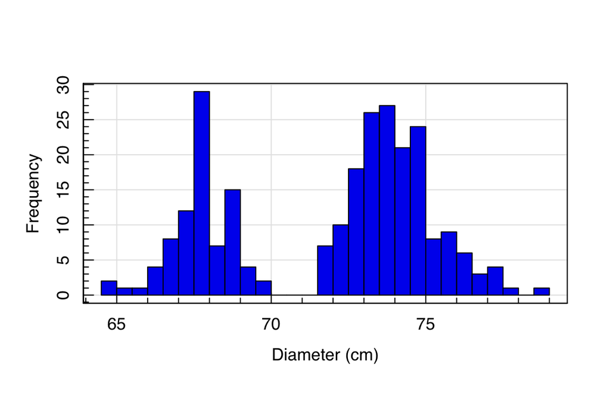

```r
#Histogram of the diameters
library(magicaxis)
maghist(df$Diameter, breaks=40,col='blue2',xlab='Diameter (cm)', ylab='Frequency',
        freq=TRUE, verbose=FALSE)
```

There appears to be two peaks here…

- Option 1: Split by Restaurant?
- Option 2: Split by Base?
- Option 3: Split by Topping?
- What’s Next

# Diameter Conditioned by Restaurant?

What about if we split the data by the Restaurant?

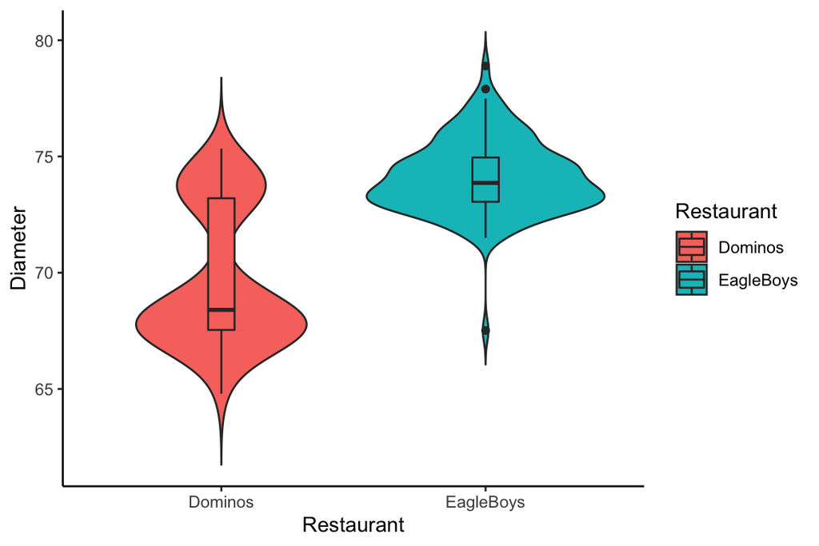

```r
#Violin plot of the diameters by Restaurant
library(ggplot2)
ggplot(df, aes(x = Restaurant, y = Diameter, fill=Restaurant)) +
  geom_violin(position = position_dodge(0.7), trim = FALSE) +
  geom_boxplot(position = position_dodge(0.7), width = 0.1) +
  theme_classic()
```

We’ve split the data here into a **conditional distribution** of diameter and Restaurant.

- Go Back

# Diameter Conditioned by Base?

What about if we split the data by the Base?

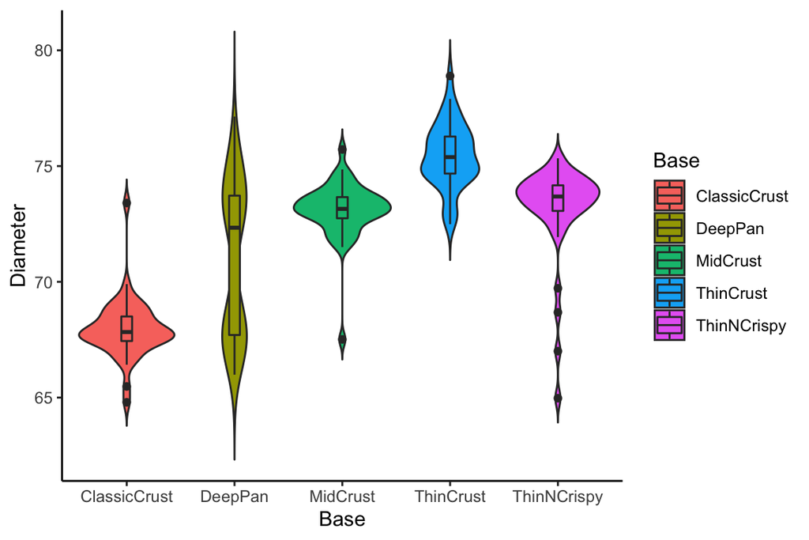

```r
#Violin plot of the diameters by Base
library(ggplot2)
ggplot(df, aes(x = Base, y = Diameter, fill=Base)) +
  geom_violin(position = position_dodge(0.7), trim = FALSE) +
  geom_boxplot(position = position_dodge(0.7), width = 0.1) +
  theme_classic()
```

We’ve split the data here into a **conditional distribution** of diameter and Base.

- Go Back

# Diameter Conditioned by Topping?

What about if we split the data by the Topping?

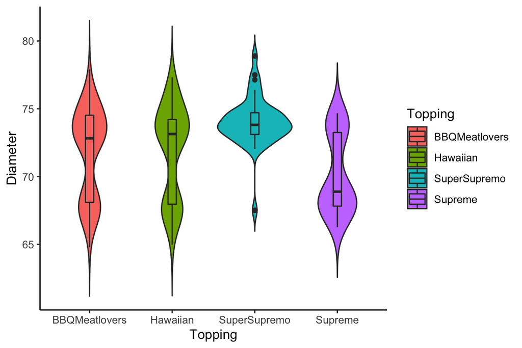

```r
#Violin plot of the diameters by Topping
library(ggplot2)
ggplot(df, aes(x = Topping, y = Diameter, fill=Topping)) +
  geom_violin(position = position_dodge(0.7), trim = FALSE) +
  geom_boxplot(position = position_dodge(0.7), width = 0.1) +
  theme_classic()
```

We’ve split the data here into a **conditional distribution** of diameter and Topping.

- Go Back

# What have we learnt?

There’s clearly joint information here that’s important..

- Restaurants clearly differ
- But there’s complexity in the base choice.

How do we decide what to order?

# Diameter conditioned on both Base and Restaurant

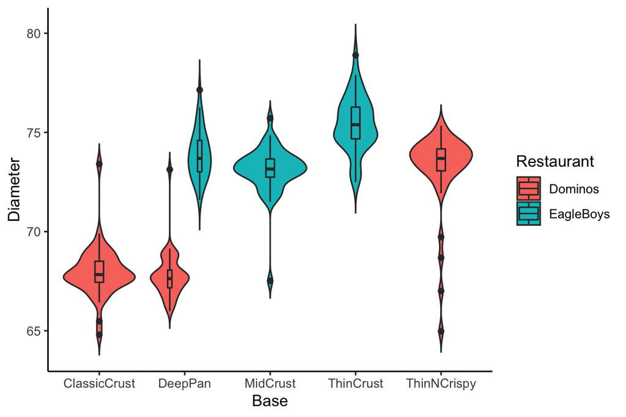

```r
#Violin plot of the diameters by Topping
library(ggplot2)
ggplot(df, aes(x = Base, y = Diameter, fill=Restaurant)) +
  geom_violin(position = position_dodge(0.7), trim = FALSE) +
  geom_boxplot(position = position_dodge(0.7), width = 0.1) +
  theme_classic()
```